# Exploratory Data Analysis - US Crime

Hannah Pavlovich

2024-02-04

```r
### GOOD PRACTICES ###
library(outliers)
library(ggplot2)
library(gridExtra)
library(randomcoloR)
library(car)
library(DAAG)
rm(list = ls())
set.seed(42) # set a seed so it everything be reproducible
```

Criminologists are interested in the effect of punishment regimes on crime rates. To this effect, data has been aggregated on 47 states for various demographic indicators. The Response variable is crime rate: number of offenses per 100,000 population in 1960.

The following performs Exploratory Data Analysis on the set provided, including outlier detection and removal.

#### Check for normality in the model with qq-norm.

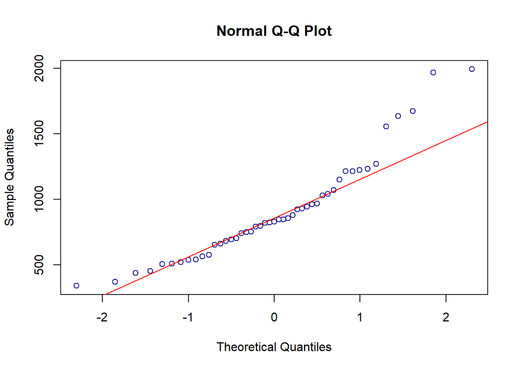

```r
### Read in the data
crimedata <- read.table("data/uscrime.txt", stringsAsFactors = FALSE, header = TRUE)
## Run crime through qqnorm
qqnorm(crimedata$Crime, col = "darkblue")
qqline(crimedata$Crime, col = "red")
```

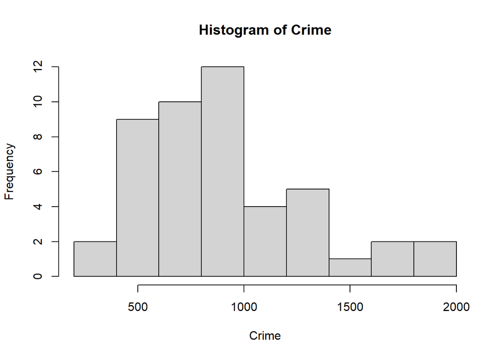

```r
## create a histogram
hist(crimedata$Crime, xlab = "Crime", main = "Histogram of Crime")
```

#### Histograms, scatterplots, and correlation matrix for each variable.

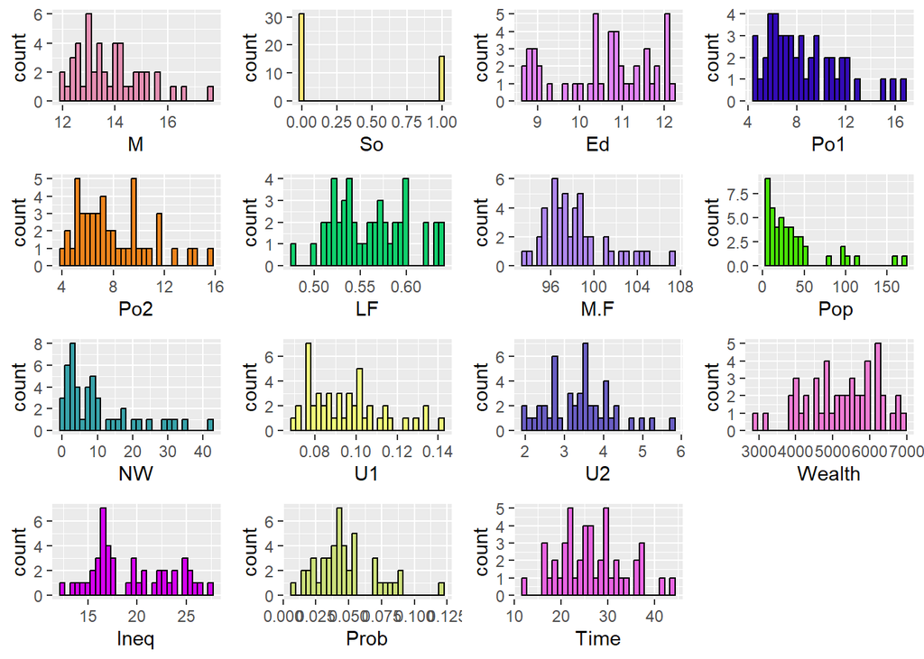

```r
## Function to create Histograms
hist_plot <- function(i){
  ggplot(crimedata, aes(x = crimedata[,i])) +
    geom_histogram( color="black", fill= randomColor()) +  xlab(names(crimedata[i]))
}

## Return Histograms

  do.call(grid.arrange, lapply(1:15, hist_plot))
```

Wealth is the only histogram that is heavier on the right side.

I next examined the scatterplots to see what the relationships are between the variables. We are using multiple variables to predict the crime rate, so it is important to see how the predictors relate to one another

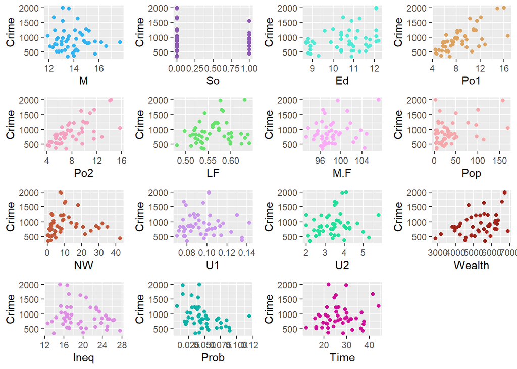

```r
## Function to create scatter plots
scat_plot <- function(i){
  ggplot(crimedata, aes(x = crimedata[,i], y = Crime)) +
    geom_point(weight = 1.5, color = randomColor()) +  xlab(names(crimedata[i]))
}

## Return scatterplots

  do.call(grid.arrange, lapply(1:15, scat_plot))
```

We can see some linear correlation especially with Po (per capita expenditure on police protection) and wealth. There also seems to be a non-linear relationship between crime and Pop (state population in 1960 in hundred thousands), NW (percentage of nonwhites in the population), and U1 and U2 (unemployment rates of urban males)

#### Outlier Detection

To check for outliers, the first step is to do an EDA of the data. I begin with the summary.

```r
summary(crimedata$Crime)
```

```
##    Min. 1st Qu.  Median    Mean 3rd Qu.    Max.
##   342.0   658.5   831.0   905.1  1057.5  1993.0
```

First inspection shows a Max that is 1,100 points higher than the Median and 900 points higher than the third quantile. This suggests there are upper outliers. The lower numbers are less extreme.

Next, I make a boxplot to inspect the data

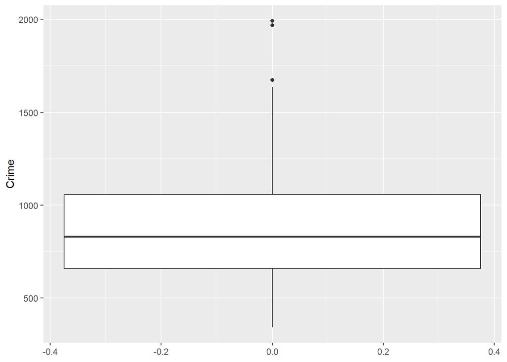

The boxplot is similar to our summary. By visual inspection, I can posit that there are at least two upper outliers.

My last EDA is with a histogram

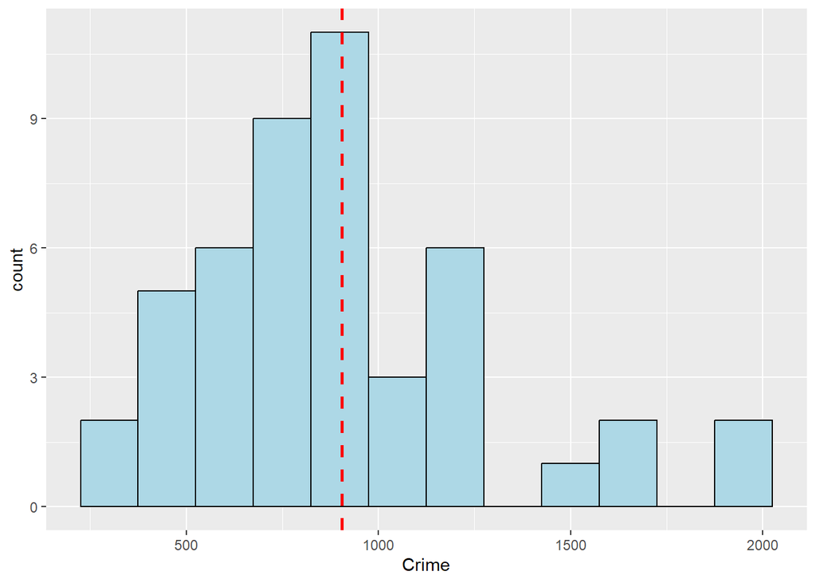

```r
ggplot(data = crimedata, aes(x=Crime)) + geom_histogram(binwidth = 150,
      color = "black", fill = "lightblue") +
      geom_vline(xintercept = mean(crimedata$Crime),
      color = "red", linetype = "dashed", size = 1
)
```

The histogram above plots the Crime data against count, with the red dashed line showing the mean of Crimes. Again, we can see that this histogram is right-side heavy, suggesting outliers.

Next, I will apply the grubbs test to see if these points are actually outliers, and to see if they will change the data.

```r
print("Grubbs Test for Highest Value:")
```

```
## [1] "Grubbs Test for Highest Value:"
```

```r
grubbs.test(crimedata$Crime)
```

```
##
##  Grubbs test for one outlier
##
## data:  crimedata$Crime
## G = 2.81287, U = 0.82426, p-value = 0.07887
## alternative hypothesis: highest value 1993 is an outlier
```

```r
print("Grubbs Test for Lowest Value")
```

```
## [1] "Grubbs Test for Lowest Value"
```

```r
grubbs.test(crimedata$Crime, opposite = TRUE)
```

```
##
##  Grubbs test for one outlier
##
## data:  crimedata$Crime
## G = 1.45589, U = 0.95292, p-value = 1
## alternative hypothesis: lowest value 342 is an outlier
```

Above, I ran the Grubbs Tests to check for outliers on the highest and lowest ends. According to this test, our high point 1993 is NOT an outlier with $\alpha$ = 0.05.

To be certain, I wanted to plot the crime data against the other predictors, one by one.

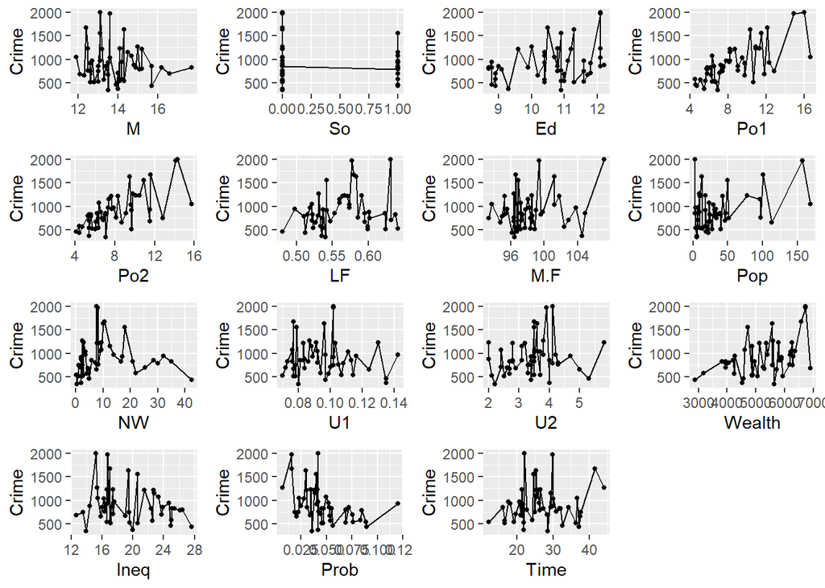

```r
library(gridExtra)

linear_plot <- function(i){
  ggplot(crimedata, aes(x = crimedata[,i], y = Crime, group = 1)) +
    geom_point(size = 1) + geom_line() + xlab(names(crimedata[i]))
}

  do.call(grid.arrange, lapply(1:15, linear_plot))
```

By quick inspection, plots against Po1 and Po2 imply some sort of linearity. While not getting too deep into this, I can reject the hypothesis that an outlier exists.